# 데이터마이닝 과제1

- 이종법 12171676 컴퓨터공학과

# 포르투칼 소매은행 정기예금 텔레마케팅 결과

다른 변수들이 정기예금 가입 여부에 어떤 영향을 주는지 EDA릍 통하여 분석하라.

# 변수 설명

```
   1 - age : 나이 (numeric)
   2 - job : 직업종류 (categorical)
admin., blue-collar, entrepreneur, housemaid, management, retired, self-employed, services, student, technician, unemployed, unknown.
   3 - marital : 결혼 상태 (categorical)
divorced, married, single, unknown.
note: divorced means divorced or widowed
   4 - education : 교육 정도 (categorical)
basic.4y, basic.6y, basic.9y, high.school, illiterate, professional.course, university.degree, unknown.
   5 - default: 신용불량 여부 (categorical)
no, yes, unknown.
   6 - housing: 주택대출 여부 (categorical)
no, yes, unknown.
   7 - loan: 개인대출 여부 (categorical)
no, yes, unknown.

   # related with the last contact of the current campaign:
   8 - contact: 접촉 유형 (categorical)
cellular, telephone
   9 - month: 마직막 접촉 월 (categorical)
jan,  feb,  mar,  ...,  nov,  dec.
  10 - day_of_week: 마지막 접촉 요일 (categorical)
mon, tue, wed, thu, fri.
  11 - duration: 마지막 접촉 통화시간 (단위:초) (numeric)

   # other attributes:
  12 - campaign: 이 캠페인에서 해당 클라이언트에 대한 접촉 횟수 (numeric)
includes last contact
  13 - pdays: 이전 캠페인에서 클라이언트에 마지막으로 연락한 후 경과한 일 수 (numeric)
999 클라이언트에 이전에 연결되지 않음을 의미함
  14 - previous: 지난 캠페인에서 해당 클라이언트에 대한 접촉 횟수 (numeric)
  15 - poutcome: 이전 마케팅 캠페인의 결과 (categorical)
failure, nonexistent, success

   # social and economic context attributes
  16 - emp.var.rate: 고용 변동률 - 분기별 지표 (numeric)
  17 - cons.price.idx: 소비자물가지수 - 월간지표 (numeric)
  18 - cons.conf.idx: 소비자 신뢰 지수 - 월간 지표 (numeric)
  19 - euribor3m: 3개월 만기 유로예금 이자율 - 일별 지표 (numeric)
  20 - nr.employed: 고용자 수 - 분기별 지표 (numeric)

  Target
  21 - y – 정기예금 가입 여부 (binary)
yes, no
```

category: 10, numeric : 10

- 이를 통해 생각해본 가설 및 변수 해석들
  - age에 따라 그룹이 구별될 것 같다. 가중치가 있는 그룹에 더미변수를 추가할것. (변수 가공)
  - (month, day_of_week)는 현재 조사시점이 언제인지와 관련이 있어보인다.pdays와 다중공선성이 있을것이라 생각됨. 분포 확인 후 제거. (변수가공)
  - unknown이 있는 컬럼들은 one-hot-encoding이 되야한다.
  - pdays는 실제 통화후 시간, previous는 실제 통화를 안해도 연락한 횟수를 말한다.
  - 16~20는 주변 상황을 의미하는 변수로, 선형 변환으로 하나로 그룹 되지 않을까? (변수 가공)
  - default 신용불량 여부 unknown은, 신용불량자가 답하지 않을 것으로 생각. 정기예금을 가입하지 않을 확률이 높다 생각한다. unknonwn은 yes로 바꿔줄 수 있지 않을까?

```python
import matplotlib.pyplot as plt
import numpy as np
from glob import glob
import pandas as pd
import sys
```

```python
#시각화 패키지들
import seaborn as sns
import matplotlib.pyplot as plt
from statsmodels.graphics.mosaicplot import mosaic
%matplotlib inline

plt.style.use("ggplot")
```

```python
#분석 관련
from scipy.stats import chi2_contingency
from scipy.stats import kstest
from statsmodels.formula.api import ols
```

# 데이터 확인

```python
# 파일 불러오기
train = pd.read_csv('./data/bank-full2.csv')
#submission = pd.read_csv('./data/sample_submission.csv')
```

더 자세하게 확인하려면, train과 test를 나눠야겠지만 과제이기 때문에 train으로 분석

```python
train
```

|  | age | job | marital | education | default | housing | loan | contact | month | day_of_week | ... | campaign | pdays | previous | poutcome | emp.var.rate | cons.price.idx | cons.conf.idx | euribor3m | nr.employed | y |
| --- | --- | --- | --- | --- | --- | --- | --- | --- | --- | --- | --- | --- | --- | --- | --- | --- | --- | --- | --- | --- | --- |
| 0 | 56 | housemaid | married | basic.4y | no | no | no | telephone | may | mon | ... | 1 | 999 | 0 | nonexistent | 1.1 | 93.994 | -36.4 | 4.857 | 5191.0 | no |
| 1 | 57 | services | married | high.school | unknown | no | no | telephone | may | mon | ... | 1 | 999 | 0 | nonexistent | 1.1 | 93.994 | -36.4 | 4.857 | 5191.0 | no |
| 2 | 37 | services | married | high.school | no | yes | no | telephone | may | mon | ... | 1 | 999 | 0 | nonexistent | 1.1 | 93.994 | -36.4 | 4.857 | 5191.0 | no |
| 3 | 40 | admin. | married | basic.6y | no | no | no | telephone | may | mon | ... | 1 | 999 | 0 | nonexistent | 1.1 | 93.994 | -36.4 | 4.857 | 5191.0 | no |
| 4 | 56 | services | married | high.school | no | no | yes | telephone | may | mon | ... | 1 | 999 | 0 | nonexistent | 1.1 | 93.994 | -36.4 | 4.857 | 5191.0 | no |
| ... | ... | ... | ... | ... | ... | ... | ... | ... | ... | ... | ... | ... | ... | ... | ... | ... | ... | ... | ... | ... | ... |
| 41183 | 73 | retired | married | professional.course | no | yes | no | cellular | nov | fri | ... | 1 | 999 | 0 | nonexistent | -1.1 | 94.767 | -50.8 | 1.028 | 4963.6 | yes |
| 41184 | 46 | blue-collar | married | professional.course | no | no | no | cellular | nov | fri | ... | 1 | 999 | 0 | nonexistent | -1.1 | 94.767 | -50.8 | 1.028 | 4963.6 | no |
| 41185 | 56 | retired | married | university.degree | no | yes | no | cellular | nov | fri | ... | 2 | 999 | 0 | nonexistent | -1.1 | 94.767 | -50.8 | 1.028 | 4963.6 | no |
| 41186 | 44 | technician | married | professional.course | no | no | no | cellular | nov | fri | ... | 1 | 999 | 0 | nonexistent | -1.1 | 94.767 | -50.8 | 1.028 | 4963.6 | yes |
| 41187 | 74 | retired | married | professional.course | no | yes | no | cellular | nov | fri | ... | 3 | 999 | 1 | failure | -1.1 | 94.767 | -50.8 | 1.028 | 4963.6 | no |

41188 rows × 21 columns

```python
#차원 확인
print("all data: ",train.shape)
```

```
all data:  (41188, 21)
```

```python
print("yes : ",sum(train['y']=='yes'))
print("no : ",sum(train['y']=='no'))
```

```
yes :  4640
no :  36548
```

라벨에 불균형이 있음을 볼 수 있다.

## 데이터 타입 확인

```python
train.info()
```

```
<class 'pandas.core.frame.DataFrame'>
RangeIndex: 41188 entries, 0 to 41187
Data columns (total 21 columns):
 #   Column          Non-Null Count  Dtype
---  ------          --------------  -----
 0   age             41188 non-null  int64
 1   job             41188 non-null  object
 2   marital         41188 non-null  object
 3   education       41188 non-null  object
 4   default         41188 non-null  object
 5   housing         41188 non-null  object
 6   loan            41188 non-null  object
 7   contact         41188 non-null  object
 8   month           41188 non-null  object
 9   day_of_week     41188 non-null  object
 10  duration        41188 non-null  int64
 11  campaign        41188 non-null  int64
 12  pdays           41188 non-null  int64
 13  previous        41188 non-null  int64
 14  poutcome        41188 non-null  object
 15  emp.var.rate    41188 non-null  float64
 16  cons.price.idx  41188 non-null  float64
 17  cons.conf.idx   41188 non-null  float64
 18  euribor3m       41188 non-null  float64
 19  nr.employed     41188 non-null  float64
 20  y               41188 non-null  object
dtypes: float64(5), int64(5), object(11)
memory usage: 6.6+ MB
```

- na는 없어 보인다. 하지만 내부에 unknown이 존재.

```python
#컬럼명 변경
# . 이 있으면 분석시 오류가 생겨서.
train.columns = train.columns.str.replace('.','_')
```

```python
train.isna().sum()
```

```
age               0
job               0
marital           0
education         0
default           0
housing           0
loan              0
contact           0
month             0
day_of_week       0
duration          0
campaign          0
pdays             0
previous          0
poutcome          0
emp_var_rate      0
cons_price_idx    0
cons_conf_idx     0
euribor3m         0
nr_employed       0
y                 0
dtype: int64
```

```python
(train=='unknown').sum()
```

```
age                  0
job                330
marital             80
education         1731
default           8597
housing            990
loan               990
contact              0
month                0
day_of_week          0
duration             0
campaign             0
pdays                0
previous             0
poutcome             0
emp_var_rate         0
cons_price_idx       0
cons_conf_idx        0
euribor3m            0
nr_employed          0
y                    0
dtype: int64
```

na가 많은 편으로 볼 수 있다.

특이하게, housing과 loan이 같은수의 na를 가진다. 이는, 주택대출 한사람이 개인대출도 했을 가능성이 높다고 보인다. 둘다 unknown을 yes로 바꿔줄 수 있지 않을까.

default는 신용불량자를 뜻하는데 target에 따른 분포를 확인해서, yes로 바꿔줄 수 있다고 생각함.

# 범주형 레벨 확인

```python
print(train.columns)
```

```
Index(['age', 'job', 'marital', 'education', 'default', 'housing', 'loan',
       'contact', 'month', 'day_of_week', 'duration', 'campaign', 'pdays',
       'previous', 'poutcome', 'emp_var_rate', 'cons_price_idx',
       'cons_conf_idx', 'euribor3m', 'nr_employed', 'y'],
      dtype='object')
```

```python
print('job \n',train['job'].unique())
print('marital \n',train['marital'].unique())
print('education \n',train['education'].unique())
print('default \n',train['default'].unique())
print('housing \n',train['housing'].unique())
print('loan \n',train['loan'].unique())
print('contact \n',train['contact'].unique())
print('month \n',train['month'].unique())
print('day_of_week \n',train['day_of_week'].unique())
print('poutcome \n',train['poutcome'].unique())
```

```
job
 ['housemaid' 'services' 'admin.' 'blue-collar' 'technician' 'retired'
 'management' 'unemployed' 'self-employed' 'unknown' 'entrepreneur'
 'student']
marital
 ['married' 'single' 'divorced' 'unknown']
education
 ['basic.4y' 'high.school' 'basic.6y' 'basic.9y' 'professional.course'
 'unknown' 'university.degree' 'illiterate']
default
 ['no' 'unknown' 'yes']
housing
 ['no' 'yes' 'unknown']
loan
 ['no' 'yes' 'unknown']
contact
 ['telephone' 'cellular']
month
 ['may' 'jun' 'jul' 'aug' 'oct' 'nov' 'dec' 'mar' 'apr' 'sep']
day_of_week
 ['mon' 'tue' 'wed' 'thu' 'fri']
poutcome
 ['nonexistent' 'failure' 'success']
```

오타가 있는 범주는 없다.

# 범주형 데이터 분석

## job

- unknow값도 존재해서, group에 포함시킬 수도 있는지 확인해본다.

target vs job

```python
job_crosstab=pd.crosstab(train['job'],train['y'])
job_crossgtab_res=chi2_contingency(job_crosstab)
```

```python
job_crosstab
```

| y job | no | yes |
| --- | --- | --- |
| admin. | 9070 | 1352 |
| blue-collar | 8616 | 638 |
| entrepreneur | 1332 | 124 |
| housemaid | 954 | 106 |
| management | 2596 | 328 |
| retired | 1286 | 434 |
| self-employed | 1272 | 149 |
| services | 3646 | 323 |
| student | 600 | 275 |
| technician | 6013 | 730 |
| unemployed | 870 | 144 |
| unknown | 293 | 37 |

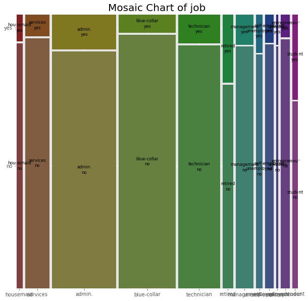

```python
plt.rcParams["figure.figsize"]=(10,10)

mosaic(train, ['job', 'y'],gap=0.01,label_rotation=True)


plt.title('Mosaic Chart of job', fontsize=20)

plt.show()
plt.rcParams["figure.figsize"]=(6.0,4.0)
```

도수만 다를 뿐, student, retired을 제외하고는 다들 비슷한 분포를 가진다.

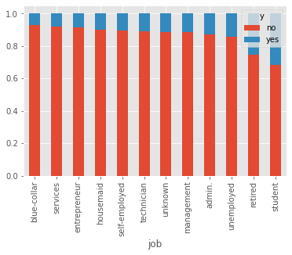

```python
#ratio plot 제작
def ratio_table(cross_tab):
    return cross_tab.div(cross_tab.sum(axis=1),axis='index')

job_ratio=ratio_table(job_crosstab)
job_ratio=job_ratio.sort_values(by='no',ascending=False)

job_ratio.plot(kind='bar',stacked=True)
```

```python
job_ratio
```

| y job | no | yes |
| --- | --- | --- |
| blue-collar | 0.931057 | 0.068943 |
| services | 0.918619 | 0.081381 |
| entrepreneur | 0.914835 | 0.085165 |
| housemaid | 0.900000 | 0.100000 |
| self-employed | 0.895144 | 0.104856 |
| technician | 0.891740 | 0.108260 |
| unknown | 0.887879 | 0.112121 |
| management | 0.887825 | 0.112175 |
| admin. | 0.870274 | 0.129726 |
| unemployed | 0.857988 | 0.142012 |
| retired | 0.747674 | 0.252326 |
| student | 0.685714 | 0.314286 |

```python
print('Chi2 Statistic: {}, p-value: {}'.format(job_crossgtab_res[0], job_crossgtab_res[1]))
print('기각')
```

```
Chi2 Statistic: 961.2424403289555, p-value: 4.189763287563623e-199
기각
```

검정 결과 job과 target은 독립이 아님을 알 수 있다.

또한, management와 unknown이 상당히 비슷해 보임을 알 수 있다.

(retired) vs (student) vs (그 외)로 grouping을 진행

```python
train_jobs = train.copy()
train_jobs['job']=train_jobs['job'].replace(['blue-collar','services','entrepreneur','housemaid','self-employed','technician',
                           'unknown','management','admin.','unemployed'],'job1')
train_jobs['job'].unique()
```

```
array(['job1', 'retired', 'student'], dtype=object)
```

```python
job_crosstab=pd.crosstab(train_jobs['job'],train['y'])
job_crossgtab_res=chi2_contingency(job_crosstab)
```

```python
print('Chi2 Statistic: {}, p-value: {}'.format(job_crossgtab_res[0], job_crossgtab_res[1]))
print('기각')
```

```
Chi2 Statistic: 736.5282532641304, p-value: 1.1612398226593737e-160
기각
```

기각하긴 하지만, pvalue가 증가하게 되었다.

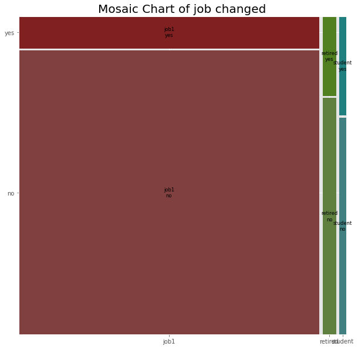

```python
plt.rcParams["figure.figsize"]=(10,10)

mosaic(train_jobs, ['job', 'y'],gap=0.01,label_rotation=True)


plt.title('Mosaic Chart of job changed', fontsize=20)

plt.show()
plt.rcParams["figure.figsize"]=(6.0,4.0)
```

## marital

```python
marital_crosstab=pd.crosstab(train['marital'],train['y'])
marital_crosstab_res=chi2_contingency(marital_crosstab)
```

```python
marital_crosstab
```

| y marital | no | yes |
| --- | --- | --- |
| divorced | 4136 | 476 |
| married | 22396 | 2532 |
| single | 9948 | 1620 |
| unknown | 68 | 12 |

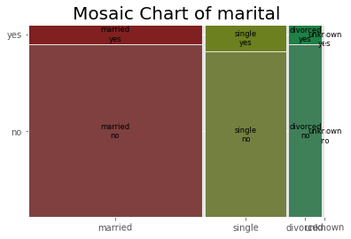

```python
mosaic(train, ['marital', 'y'],gap=0.01,label_rotation=True)


plt.title('Mosaic Chart of marital', fontsize=20)

plt.show()
```

욱안으로는 결혼 여부는 큰 영향을 안주는 것으로 관측된다.

```python
marital_crosstab
```

| y marital | no | yes |
| --- | --- | --- |
| divorced | 4136 | 476 |
| married | 22396 | 2532 |
| single | 9948 | 1620 |
| unknown | 68 | 12 |

```python
print('Chi2 Statistic: {}, p-value: {}'.format(marital_crosstab_res[0], marital_crosstab_res[1]))
print('기각')
```

```
Chi2 Statistic: 122.65515182252989, p-value: 2.068014648442211e-26
기각
```

그래도 카이제곱 검정은 기각을 한다. 결혼여부에 따라 다르다고 할 수 있다.

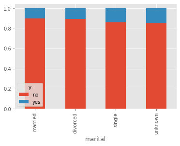

```python
marital_ratio=ratio_table(marital_crosstab)
marital_ratio=marital_ratio.sort_values(by='no',ascending=False)

marital_ratio.plot(kind='bar',stacked=True)
```

```python
marital_ratio
```

| y marital | no | yes |
| --- | --- | --- |
| married | 0.898427 | 0.101573 |
| divorced | 0.896791 | 0.103209 |
| single | 0.859959 | 0.140041 |
| unknown | 0.850000 | 0.150000 |

married와 divorced는 거의 같다고 할 수 있어서, 둘을 합쳐준다.

unknown과 single도 매우 유사하다.

```python
train_marital = train.copy()
train_marital['marital']=train_marital['marital'].replace(['married','divorced'],'marital1')
train_marital['marital']=train_marital['marital'].replace(['single','unknown'],'marital2')
train_marital['marital'].unique()
```

```
array(['marital1', 'marital2'], dtype=object)
```

```python
marital_crosstab=pd.crosstab(train_marital['marital'],train['y'])
marital_crosstab_res=chi2_contingency(marital_crosstab)
print('Chi2 Statistic: {}, p-value: {}'.format(marital_crosstab_res[0], marital_crosstab_res[1]))
print('기각')
```

```
Chi2 Statistic: 122.08940156886162, p-value: 2.206669293572927e-28
기각
```

grouping 후에 오히려, p-value가 감소했다.

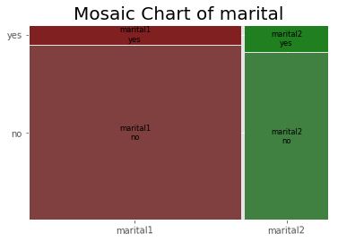

```python
mosaic(train_marital, ['marital', 'y'],gap=0.01,label_rotation=True)


plt.title('Mosaic Chart of marital', fontsize=20)

plt.show()
```

## education

```python
education_crosstab=pd.crosstab(train['education'],train['y'])
education_crosstab_res=chi2_contingency(education_crosstab)
```

```python
education_crosstab
```

| y education | no | yes |
| --- | --- | --- |
| basic.4y | 3748 | 428 |
| basic.6y | 2104 | 188 |
| basic.9y | 5572 | 473 |
| high.school | 8484 | 1031 |
| illiterate | 14 | 4 |
| professional.course | 4648 | 595 |
| university.degree | 10498 | 1670 |
| unknown | 1480 | 251 |

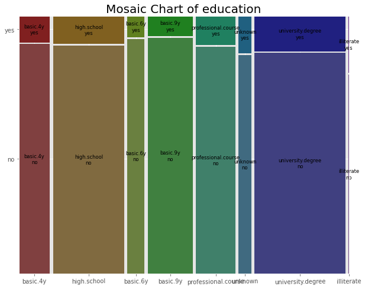

```python
plt.rcParams["figure.figsize"]=(10,8)
mosaic(train, ['education', 'y'],gap=0.01,label_rotation=True)
plt.title('Mosaic Chart of education', fontsize=20)

plt.show()
plt.rcParams["figure.figsize"]=(6.0,4.0)
```

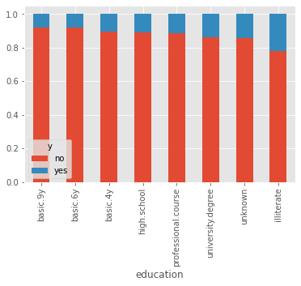

```python
#ratio plot 제작
education_ratio=ratio_table(education_crosstab)
education_ratio=education_ratio.sort_values(by='no',ascending=False)

education_ratio.plot(kind='bar',stacked=True)
```

```python
print('Chi2 Statistic: {}, p-value: {}'.format(education_crosstab_res[0], education_crosstab_res[1]))
print('기각')
```

```
Chi2 Statistic: 193.10590454149565, p-value: 3.3051890144025054e-38
기각
```

```python
education_ratio
```

| y education | no | yes |
| --- | --- | --- |
| basic.9y | 0.921754 | 0.078246 |
| basic.6y | 0.917976 | 0.082024 |
| basic.4y | 0.897510 | 0.102490 |
| high.school | 0.891645 | 0.108355 |
| professional.course | 0.886515 | 0.113485 |
| university.degree | 0.862755 | 0.137245 |
| unknown | 0.854997 | 0.145003 |
| illiterate | 0.777778 | 0.222222 |

basic과 highschool / profess / university, unknown / illiterate로 나눠보자

```python
train_education = train.copy()
train_education['education']=train_education['education'].replace(['basic.9y','basic.6y','basic.4y','high.school'],'education1')
train_education['education']=train_education['education'].replace(['university.degree','unknown'],'university.degree')
train_education['education'].unique()
```

```
array(['education1', 'professional.course', 'university.degree',
       'illiterate'], dtype=object)
```

```python
education_crosstab=pd.crosstab(train_education['education'],train['y'])
education_crosstab_res=chi2_contingency(education_crosstab)
```

```python
education_crosstab
```

| y education | no | yes |
| --- | --- | --- |
| education1 | 19908 | 2120 |
| illiterate | 14 | 4 |
| professional.course | 4648 | 595 |
| university.degree | 11978 | 1921 |

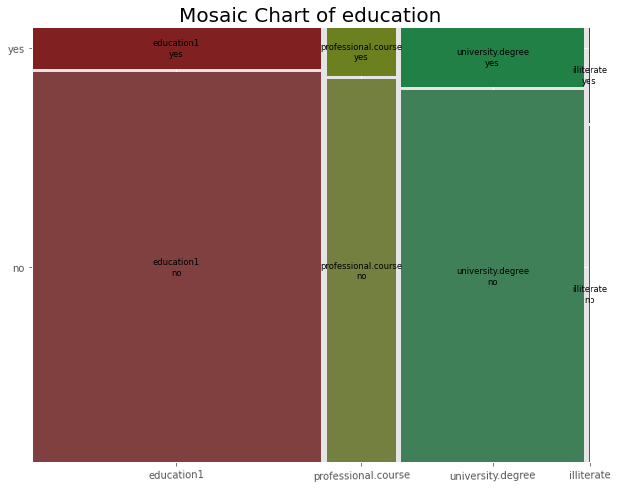

```python
plt.rcParams["figure.figsize"]=(10,8)
mosaic(train_education, ['education', 'y'],gap=0.01,label_rotation=True)
plt.title('Mosaic Chart of education', fontsize=20)

plt.show()
plt.rcParams["figure.figsize"]=(6.0,4.0)
```

```python
print('Chi2 Statistic: {}, p-value: {}'.format(education_crosstab_res[0], education_crosstab_res[1]))
print('기각')
```

```
Chi2 Statistic: 152.37803568673755, p-value: 8.086373337274164e-33
기각
```

잘 구분되었음을 볼 수 있다.

## default

가설로 unknown은 신용불량자가 아닐까 제안했다. 그것을 확인해본다.

```python
default_crosstab=pd.crosstab(train['default'],train['y'])
default_crosstab_res=chi2_contingency(default_crosstab)
```

```python
default_crosstab
```

| y default | no | yes |
| --- | --- | --- |
| no | 28391 | 4197 |
| unknown | 8154 | 443 |
| yes | 3 | 0 |

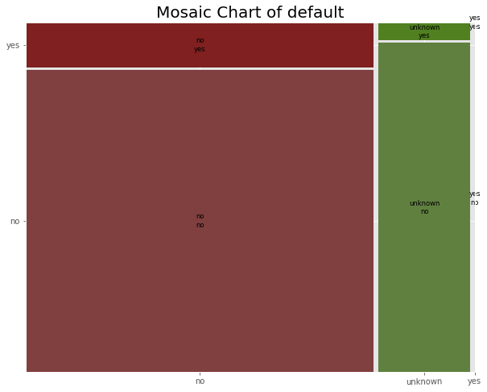

```python
plt.rcParams["figure.figsize"]=(10,8)

mosaic(train, ['default', 'y'],gap=0.01,label_rotation=True)


plt.title('Mosaic Chart of default', fontsize=20)

plt.show()
plt.rcParams["figure.figsize"]=(6,4)
```

스스로 신용불량자라 말하지 못한 것으로 보이고, 다들 unknown에 있다.

```python
train_default = train.copy()
train_default['default']=train_default['default'].replace(['unknown'],'yes')
train_default['default'].unique()
```

```
array(['no', 'yes'], dtype=object)
```

## housing & loan

가설로 housing과 loan이 둘다 unknown이면 yes일 수 있다고 생각.

```python
housing_crosstab=pd.crosstab(train['housing'],train['y'])
housing_crosstab_res=chi2_contingency(housing_crosstab)

loan_crosstab=pd.crosstab(train['loan'],train['y'])
loan_crosstab_res=chi2_contingency(loan_crosstab)
```

```python
housing_crosstab
```

| y housing | no | yes |
| --- | --- | --- |
| no | 16596 | 2026 |
| unknown | 883 | 107 |
| yes | 19069 | 2507 |

```python
loan_crosstab
```

| y loan | no | yes |
| --- | --- | --- |
| no | 30100 | 3850 |
| unknown | 883 | 107 |
| yes | 5565 | 683 |

```python
print('housing Chi2 Statistic: {}, p-value: {}'.format(housing_crosstab_res[0], housing_crosstab_res[1]))
print('loan Chi2 Statistic: {}, p-value: {}'.format(loan_crosstab_res[0], loan_crosstab_res[1]))
```

```
housing Chi2 Statistic: 5.684495858974168, p-value: 0.05829447669453452
loan Chi2 Statistic: 1.094027551150338, p-value: 0.5786752870441754
```

!중요 loan과 housing은 구분력이 없음을 볼 수있다.

[figure not shown]

```python
mosaic(train, ['housing', 'y'],gap=0.01,label_rotation=True)
plt.title('Mosaic Chart of contact', fontsize=20)
```

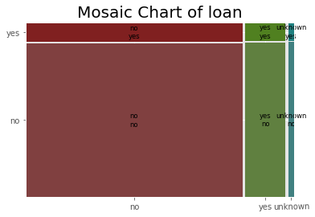

```python
mosaic(train, ['loan', 'y'],gap=0.01,label_rotation=True)
plt.title('Mosaic Chart of loan', fontsize=20)

plt.show()
```

housing과 loan은 제거.

## last contact

위 3개는 필요없는 컬럼들이라 생각을 했고, 확인해본다.

poutcome은 영향이 크다 생각했다.

- contact ('telephone' 'cellular')
- month ('may' 'jun' 'jul' 'aug' 'oct' 'nov' 'dec' 'mar' 'apr' 'sep')
- day_of_week ('mon' 'tue' 'wed' 'thu' 'fri')
- poutcome ('nonexistent' 'failure' 'success')

```python
contact_crosstab=pd.crosstab(train['contact'],train['y'])
contact_crosstab_res=chi2_contingency(contact_crosstab)

month_crosstab=pd.crosstab(train['month'],train['y'])
month_crosstab_res=chi2_contingency(month_crosstab)

day_of_week_crosstab=pd.crosstab(train['day_of_week'],train['y'])
day_of_week_crosstab_res=chi2_contingency(day_of_week_crosstab)

poutcome_crosstab=pd.crosstab(train['poutcome'],train['y'])
poutcome_crosstab_res=chi2_contingency(poutcome_crosstab)

print('contact_crosstab Chi2 Statistic: {}, p-value: {}'.format(contact_crosstab_res[0], contact_crosstab_res[1]))
print('month_crosstab Chi2 Statistic: {}, p-value: {}'.format(month_crosstab_res[0], month_crosstab_res[1]))
print('day_of_week_crosstab Chi2 Statistic: {}, p-value: {}'.format(day_of_week_crosstab_res[0], day_of_week_crosstab_res[1]))
print('poutcome_crosstab_res Chi2 Statistic: {}, p-value: {}'.format(poutcome_crosstab_res[0], poutcome_crosstab_res[1]))
```

```
contact_crosstab Chi2 Statistic: 862.3183642075705, p-value: 1.5259856523129964e-189
month_crosstab Chi2 Statistic: 3101.149351411678, p-value: 0.0
day_of_week_crosstab Chi2 Statistic: 26.14493907587197, p-value: 2.9584820052785324e-05
poutcome_crosstab_res Chi2 Statistic: 4230.5237978319765, p-value: 0.0
```

예상과 다르게 모두 영향이 있다고 나온다.

그중, 몇월이냐와 이전 결과가 가장 영향이 크다.

[figure not shown]

```python
mosaic(train, ['contact', 'y'],gap=0.01,label_rotation=True)
plt.title('Mosaic Chart of housing', fontsize=20)
```

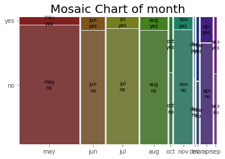

```python
mosaic(train, ['month', 'y'],gap=0.01,label_rotation=True)
plt.title('Mosaic Chart of month', fontsize=20)
```

월마다, 도수와 비율이 다르다.

```python
month_crosstab
```

| y month | no | yes |
| --- | --- | --- |
| apr | 2093 | 539 |
| aug | 5523 | 655 |
| dec | 93 | 89 |
| jul | 6525 | 649 |
| jun | 4759 | 559 |
| mar | 270 | 276 |
| may | 12883 | 886 |
| nov | 3685 | 416 |
| oct | 403 | 315 |
| sep | 314 | 256 |

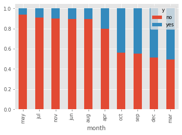

```python
#ratio plot 제작
month_ratio=ratio_table(month_crosstab)
month_ratio=month_ratio.sort_values(by='no',ascending=False)

month_ratio.plot(kind='bar',stacked=True)
```

```python
month_ratio
```

| y month | no | yes |
| --- | --- | --- |
| may | 0.935653 | 0.064347 |
| jul | 0.909534 | 0.090466 |
| nov | 0.898561 | 0.101439 |
| jun | 0.894885 | 0.105115 |
| aug | 0.893979 | 0.106021 |
| apr | 0.795213 | 0.204787 |
| oct | 0.561281 | 0.438719 |
| sep | 0.550877 | 0.449123 |
| dec | 0.510989 | 0.489011 |
| mar | 0.494505 | 0.505495 |

may / jul,nov,jun, aug / apr / oct,sep / dec,mar/ 로 구분할 수 있다.

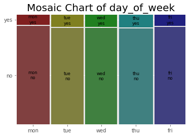

```python
mosaic(train, ['day_of_week', 'y'],gap=0.01,label_rotation=True)
plt.title('Mosaic Chart of day_of_week', fontsize=20)
```

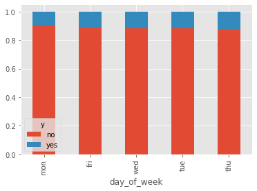

```python
#ratio plot 제작
day_of_week_ratio=ratio_table(day_of_week_crosstab)
day_of_week_ratio=day_of_week_ratio.sort_values(by='no',ascending=False)

day_of_week_ratio.plot(kind='bar',stacked=True)
```

```python
day_of_week_crosstab
```

| y day_of_week | no | yes |
| --- | --- | --- |
| fri | 6981 | 846 |
| mon | 7667 | 847 |
| thu | 7578 | 1045 |
| tue | 7137 | 953 |
| wed | 7185 | 949 |

```python
day_of_week_ratio
```

| y day_of_week | no | yes |
| --- | --- | --- |
| mon | 0.900517 | 0.099483 |
| fri | 0.891913 | 0.108087 |
| wed | 0.883329 | 0.116671 |
| tue | 0.882200 | 0.117800 |
| thu | 0.878812 | 0.121188 |

mon,fri / tue,wed,thu 으로 구분이된다.

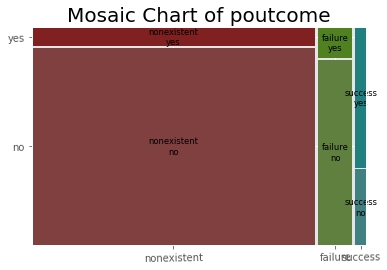

```python
mosaic(train, ['poutcome', 'y'],gap=0.01,label_rotation=True)
plt.title('Mosaic Chart of poutcome', fontsize=20)
```

poutcome은 nonexistent 자체가 새로운 값이다.